| Hazırlayan | Versiyon | Tarih | Dil |
| --- | --- | --- | --- |
| dataFLOYD | v1.00 | 13 Eyl 2018 | TR |

Başlamadan önce henüz bakmadıysanız aşağıdaki yazıları gözden geçirmenizi öneririm  
ÖN KOŞULLAR  
[Temel Python kullanımı](https://www.datafloyd.com/tr/veri-bilimi-icin-temel-python-kullanimi/)  
[Numpy kütüphanesi kullanımı](https://www.datafloyd.com/tr/pyhton-numpy-kutuphanesinin-kullanimi/)  
[Python “matplotlib” kütüphanesini kullanarak temel görselleştirme](https://www.datafloyd.com/tr/pyhton-matplotlib-kutuphanesini-kullanarak-veri-gorsellestirme-temel-grafikler%C2%B6/)  
["Confusion matrix" hakkında](https://www.datafloyd.com/tr/confusion-matrix-hakkinda/)

# YAPAY SİNİR AĞLARI (NEURAL NETWORKS) 1. BÖLÜM

TEK BİR NÖRON HAKKINDA

**Soru :** Nereden başlasak bilemedim ki? Siz yönlendirin bari..

**Cevap :** Bence başlamadan önce "ihtiyacımız olacak kadar" matrislere bakalım. Çünkü az sonra bunların grafiksel gösterimleri önem kazanacak.  
$W$, ve $x$ adında iki tane sütun matrisimiz ve bir adet $b$ adında sabit terimimiz olsun.

\begin{equation*} W= \begin{bmatrix} w_0 \\ \vdots \\ w_n \end{bmatrix} \quad x= \begin{bmatrix} x_0 \\ \vdots \\ x_n \end{bmatrix} \quad b \end{equation*}

Şimdi $y=W^Tx+b$ yazdığımızda ne olur?

\begin{equation*}y=w_0x_0+...+w_nx_n + b\end{equation*}

Şimdi bu matris çarpımı olarak yazıdğımız denklem aslında toplam olarak da ifade edilebilir. Onu da yazalım:

\begin{equation*}y=W^Tx+b=\sum_{i=0}^n{w_ix_i}+b\end{equation*}

**Soru :** dataFLOYD bey iyi ki yönlendirmeyi size bıraktık... Denkleme boğdunuz bizi, ne demek bu denklemler, neler oluyor?

**Cevap :** Yani tabi ama, ne bileyim, neyse... Bu denklemleri bir de grafik olarak göstereyim belki işe yarar.

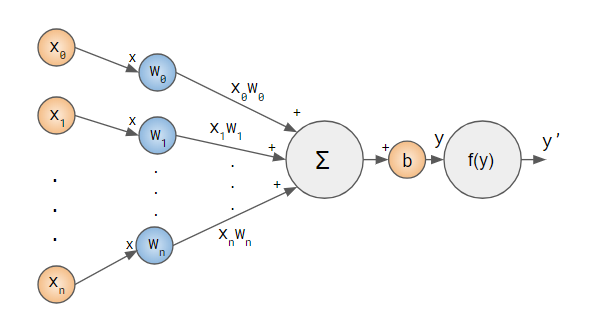

Bu şekil her kaynakta farklı farklı gösterilir fakat temelde yapılan şey aynıdır. Girdileri ağırlıklarla çarp ve topla,sonrasında ise sabit bir terim ekle.

Şekilde birşey daha dikkatinizi çekti mi? Şeklin en sonunda bir fonksiyon mevcut. Bu fonksiyona **aktivasyon fonksiyonu** denilmektedir. **Aktivasyon fonksiyonu** ortaya çıkan y değerinin non-lineer şekilde davranmasını sağlamaktadır.

Yukarıdaki şekildeki yapı genellikler **tek bir nöron** olarak tanımlanmaktadır.

Tek bir nöron denklemini aktivasyon fonksiyonunu da kullanarak tanılayalım

\begin{equation*}y'=f(W^Tx+b)=f(\sum_{i=0}^n{w_ix_i}+b)\end{equation*}

**Soru :** Aktivasyon fonksiyonu sürpriz oldu doğrusu. Bu fonksiyon nasıl bir şeydir? Türleri var mıdır?

**Cevap :** Aktivasyon fonksiyonunun non-lineer davranışı sınıflandırıcının kompleks ilişkileri öğrenebilmesini sağlar. Ne güzel laf değil mi:) İsterseniz en çok bilinen aktivasyon fonksiyonlarını gözden geçirelim.

Bu kısma geçmeden önce **"vanishing gradient"** probleminden biraz haberimiz olması gerekiyor.  
Henüz mimarilere geçmedik ama şunu bilseniz yeterli bu kötü birşeydir :). Yapay sinir ağının eğitimini çok uzatır ve "accuracy" değerini düşürür.  
Niye böyle oluyor, çünkü "backpropagation" yaparken hata değerleri geriye doğru gittikçe küçülüyor. Çok küçülmesi baştaki katmanların iyi bir şekilde öğrenmesini engelliyor. Haliyle ilk katmanlar düzgün öğrenemediği sonraki gelen katmalar da düzgün çalışamıyor.  
Konuyu ayrıntılı olarak incelemek isterseniz aşağıdaki makaleleri tavsiye ederim.  
[Why are deep neural networks hard to train?](http://neuralnetworksanddeeplearning.com/chap5.html)  
[The vanishing gradient problem](https://ayearofai.com/rohan-4-the-vanishing-gradient-problem-ec68f76ffb9b)

### ADIM FONKSİYONU (STEP FUNCTION)

Bu fonksiyon 1 veya 0 çıktısı verir. Genellikle ikiili sınıflandırma problemlerinde "perceptron" sınıflandırıcısı ile birlikte kullanılır.

*Not: "Perceptron" girdileri lineer olarak birleştirerek tahmin yapmaya çalışan bir ikili sınıflandırma algoritmasıdır.*

```python
import numpy as np
import matplotlib.pyplot as plt
# Seaborn dark theme tercihimizdir :)
import seaborn as sns
sns.set_style("darkgrid")

%matplotlib notebook
```

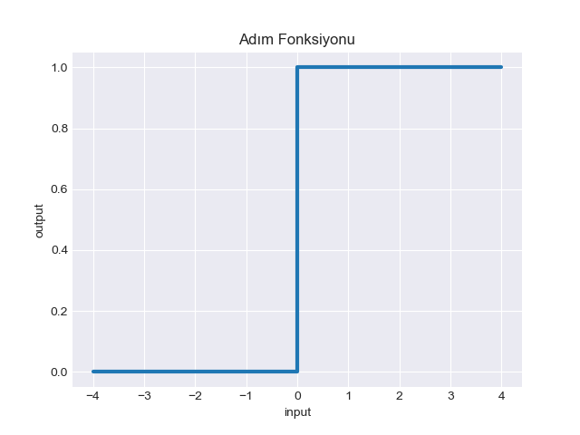

```python
plt.figure()
plt.step([-4,0,4],[0,0,1],linewidth=3)
plt.xlabel("input")
plt.ylabel("output")
plt.title("Adım Fonksiyonu");
```

### TANH

Çok büyük sayıları 1'e çok küçük sayıları -1'e sıkıştırır. *"Vanishing Gradient" problemi mevcut*

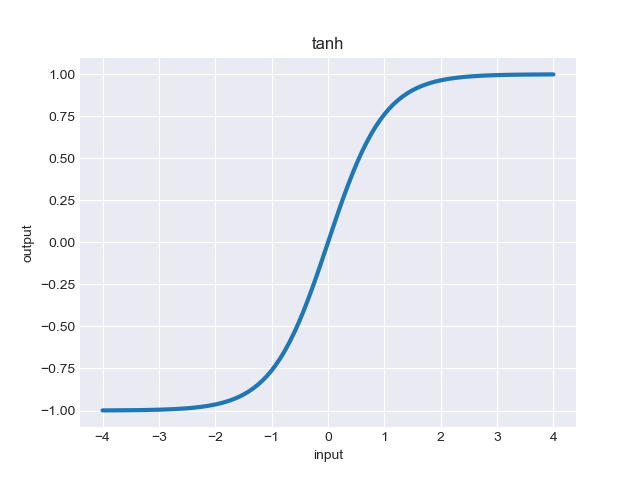

```python
plt.figure()
x = np.linspace(-4,4,100) # -1 ile 1 arasında x oluşturalım
plt.plot(x,np.tanh(x),linewidth=3)
plt.xlabel("input")
plt.ylabel("output")
plt.title("tanh");
```

### ATAN

Girdileri $-\pi/2$ ile $\pi/2$ arasına sıkıştırır. *tanh* ile 0 civarında benzer bir karakteristik sergiler fakat tanh'ye göre daha yumuşaktır. *"Vanishing Gradient" problemi mevcut*

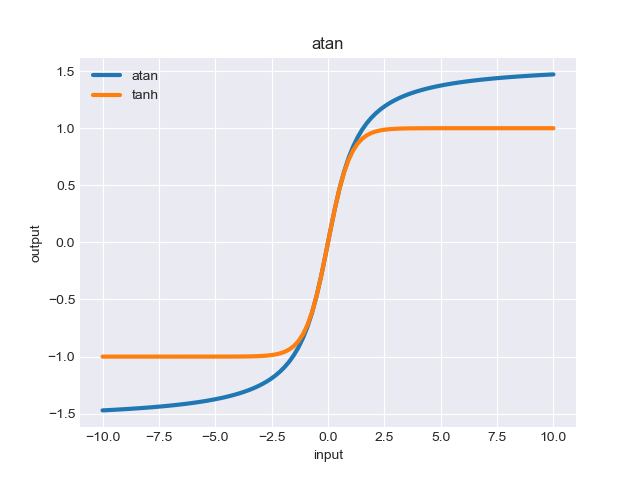

```python
plt.figure()
x = np.linspace(-10,10,100) # -1 ile 1 arasında x oluşturalım
plt.plot(x,np.arctan(x),linewidth=3)
plt.plot(x,np.tanh(x),linewidth=3)
plt.xlabel("input")
plt.ylabel("output")
plt.title("atan")
plt.legend(["atan","tanh"]);
```

### HARD TANH

*tanh* fonksiyonuna göre işlem yükü daha azdır.

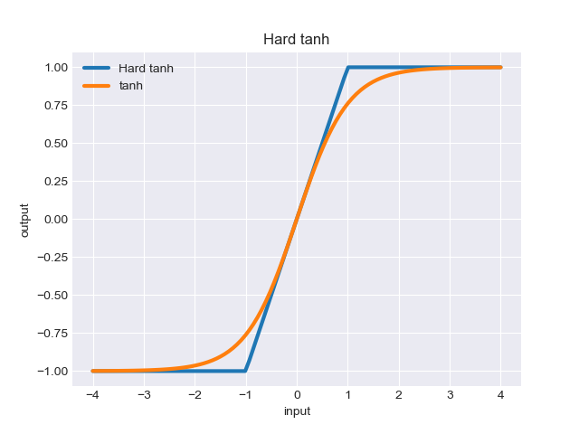

```python
plt.figure()
x = np.linspace(-4,4,100) # -1 ile 1 arasında x oluşturalım
plt.plot(x,np.maximum(-1, np.minimum(1, x)),linewidth=3)
plt.plot(x,np.tanh(x),linewidth=3)
plt.xlabel("input")
plt.ylabel("output")
plt.title("Hard tanh");
plt.legend(["Hard tanh","tanh"]);
```

### SIGMOID

Girdileri 0 ile 1 arasına sıkıştırır. *"Vanishing Gradient" problemi mevcut*

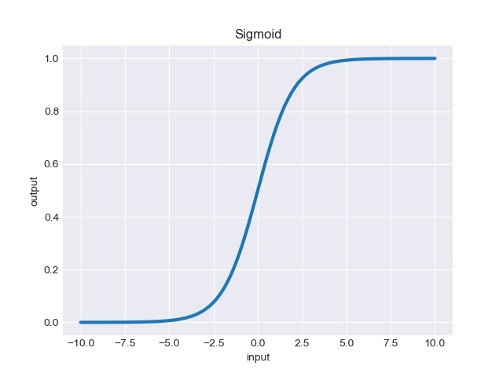

```python
plt.figure()
x = np.linspace(-10,10,100) # -1 ile 1 arasında x oluşturalım
plt.plot(x,1 / (1 + np.exp(-x)),linewidth=3)
plt.xlabel("input")
plt.ylabel("output")
plt.title("Sigmoid");
```

### RELU (RECTIFIED LINEAR UNIT)

Çok kral bir fonksiyondur :) "Vanishing gradient" problemi yoktur. Bu sebeple derin öğrenmede daha hızlı ve kesin sonuç alabilmemizi sağlar.

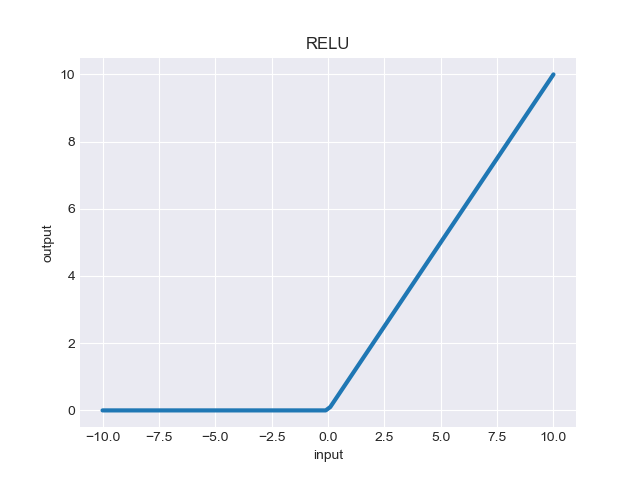

```python
plt.figure()
x = np.linspace(-10,10,100) # -1 ile 1 arasında x oluşturalım
plt.plot(x,np.maximum(0, x),linewidth=3)
plt.xlabel("input")
plt.ylabel("output")
plt.title("RELU");
```

### LEAKY RELU

RELU verken niye buna ihtiyaç çıktı denilebilir. Ne yazık ki bazen RELU'lar ölebiliyor (dying relu problem) ve girdilere hiç tepki vermiyor. Eğitim aşamasında bunun önüne geçebilmek için RELU'nun 0 olan kısmına hafif eğim verilir.

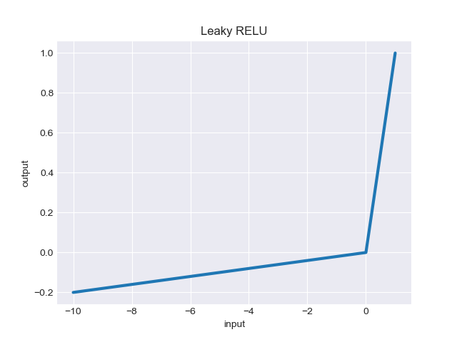

```python
plt.figure()
x = np.linspace(-10,1,100) # -1 ile 1 arasında x oluşturalım
plt.plot(x,np.maximum(0.02 * x, x),linewidth=3)
plt.xlabel("input")
plt.ylabel("output")
plt.title("Leaky RELU");
```

Şimdilik bu kadar yetsin, yoruldum :) Bu serinin devamı gelecek, bir sonraki bölümde **mimarileri ve "backpropagation"** olayını anlatacağım. Tekrar görüşünceye kadar hoşçakalın!